# Weight Lifting Excersise calssification - ML Course Project

Erika R. Frits

2018-05-28

## Summary

The goal of this analysis is to find a machine learning method which can classify  
perfomed weight lifting excercises based on their fashion; was it executed according to the description or had different kind of errors? More information here: http://groupware.les.inf.puc-rio.br/har

## Exploration of the data

We got two dataset:

- training: larger dataset to create and validate the classifaction model
- testing: smaller, which contain data to classify

Summary:

```
##                            obs variables variables <= 90% NA
## for training and testing 19622       160                  93
## to predict                  20       160                  60
```

I found that the variables which fillment rate is below 10%, are derived variables, which counterpart are also not filled in the test set. I decided to remove these variables from the data sets, so I started with the raw measurement data. I also removed the timestamp information and the **new_window** variable, because they are data about the circumstances of the measurement and not about the execution of the exercise.

### Correlation between the measured variables

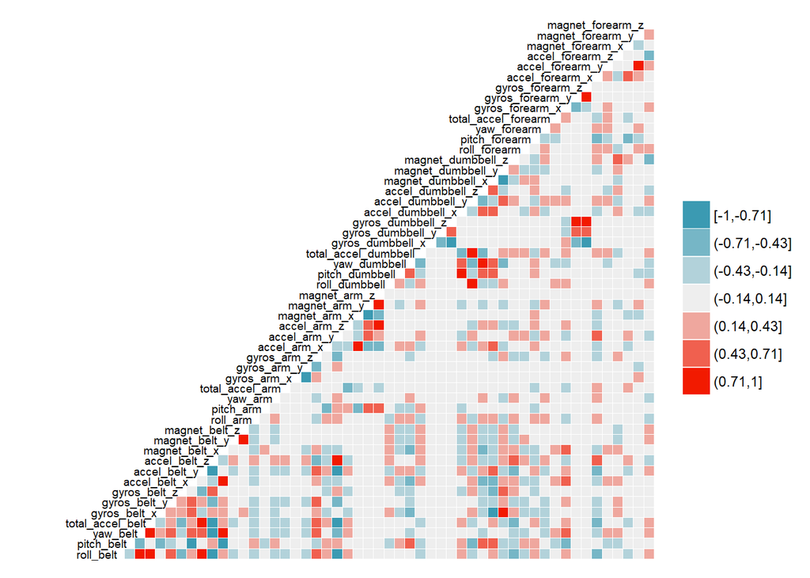

Most of the variables are not or just slightly correlated with each other.

### Checking the factors

I found that , that in case of some variables the values are differ based on the **user_name**, so I left this variable in the data set.

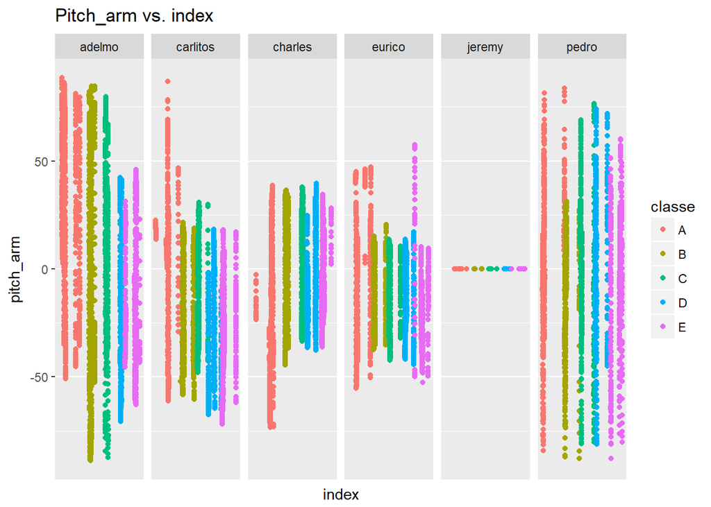

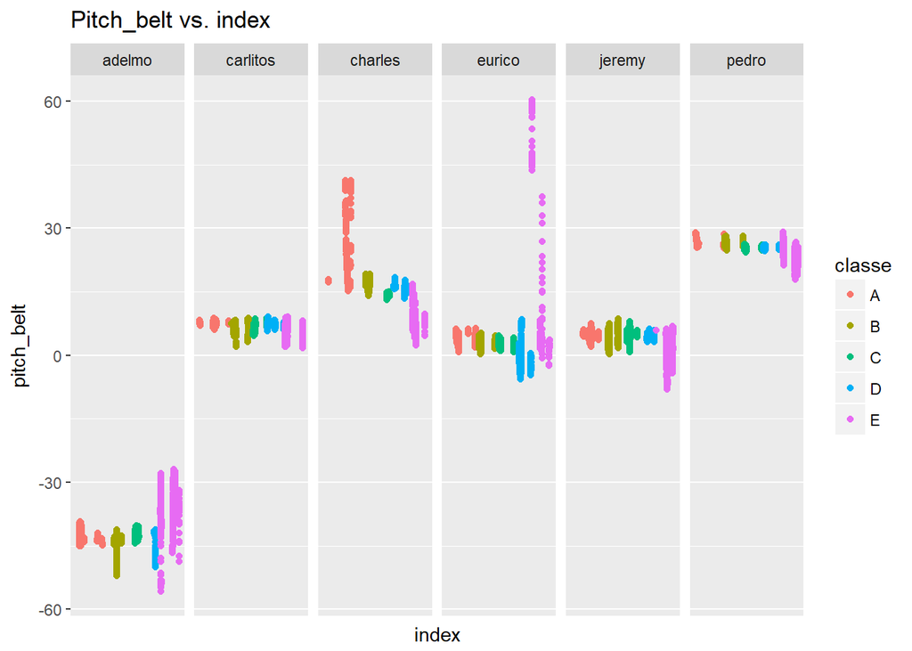

### Converting the data

I supposed (based on the data provider’s article), that one execution of the excersise is identified by one **num_window** value, so I compressed the data set by replacing the measured data points for every **num_window** by their mean values and I handled all “window” as one data point (the **num_window** variable is not a predictor).

Note: the test data set contains only one record per **num_window** so it does not need aggreagation.

## Fitting the model using random forest method

I split the training data set to two groups, 70% of the data will be used to fit the model, 30% will used for model testing.

```
##          obs
## training 602
## testing  256
```

I use 10-fold cross validation together with random forest and let the model select the best.

The fitted model:

```
## Random Forest
##
## 602 samples
##  53 predictor
##   5 classes: 'A', 'B', 'C', 'D', 'E'
##
## No pre-processing
## Resampling: Cross-Validated (10 fold)
## Summary of sample sizes: 540, 542, 543, 541, 542, 540, ...
## Resampling results across tuning parameters:
##
##   mtry  Accuracy   Kappa
##    2    0.8671240  0.8302131
##   29    0.8637342  0.8263500
##   57    0.8652359  0.8280697
##
## Accuracy was used to select the optimal model using the largest value.
## The final value used for the model was mtry = 2.
```

Result of the model tesing:

```
## Confusion Matrix and Statistics
##
##           Reference
## Prediction  A  B  C  D  E
##          A 64  3  3  2  1
##          B  1 43  3  0  2
##          C  0  0 42  2  1
##          D  1  0  1 43  2
##          E  0  0  0  2 40
##
## Overall Statistics
##
##                Accuracy : 0.9062
##                  95% CI : (0.8637, 0.939)
##     No Information Rate : 0.2578
##     P-Value [Acc > NIR] : < 2.2e-16
##
##                   Kappa : 0.8819
##  Mcnemar's Test P-Value : NA
##
## Statistics by Class:
##
##                      Class: A Class: B Class: C Class: D Class: E
## Sensitivity            0.9697   0.9348   0.8571   0.8776   0.8696
## Specificity            0.9526   0.9714   0.9855   0.9807   0.9905
## Pos Pred Value         0.8767   0.8776   0.9333   0.9149   0.9524
## Neg Pred Value         0.9891   0.9855   0.9668   0.9713   0.9720
## Prevalence             0.2578   0.1797   0.1914   0.1914   0.1797
## Detection Rate         0.2500   0.1680   0.1641   0.1680   0.1562
## Detection Prevalence   0.2852   0.1914   0.1758   0.1836   0.1641
## Balanced Accuracy      0.9612   0.9531   0.9213   0.9291   0.9300
```

The accurancy of the model on the testing data is 90.625%.

## Prediction

```
##    problem_id result
## 1           1      B
## 2           2      A
## 3           3      A
## 4           4      A
## 5           5      A
## 6           6      E
## 7           7      D
## 8           8      B
## 9           9      A
## 10         10      A
## 11         11      A
## 12         12      A
## 13         13      B
## 14         14      A
## 15         15      E
## 16         16      E
## 17         17      A
## 18         18      B
## 19         19      B
## 20         20      B
```